# 威斯康星乳腺癌数据集分类 - ANN人工神经网络

课程大作业

# 基于人工神经网络（ANN）的乳腺癌分类实验报告

**作者**：宋禾丰 **日期**：2026-06-09  
**环境**：Python + PyTorch + Jupyter Notebook

> 本实验使用乳腺癌数据集构建人工神经网络（ANN），完成二分类任务，并对模型训练过程与结果进行可视化分析。

## 1. 数据加载与预处理

```python
import pandas as pd
import numpy as np
import matplotlib.pyplot as plt
import seaborn as sns
import torch
import torch.nn as nn
import torch.optim as optim
from sklearn.model_selection import train_test_split
from sklearn.preprocessing import StandardScaler
from sklearn.metrics import accuracy_score, confusion_matrix, classification_report

# 设置中文显示（可选，防止乱码）
plt.rcParams['font.sans-serif'] = ['SimHei']
plt.rcParams['axes.unicode_minus'] = False
```

## 2. 数据集划分与标准化

将数据按 8:2 划分为训练集/测试集，并对特征做标准化处理，提升神经网络收敛速度与稳定性。

```python
df = pd.read_csv(r"D:\data.csv")
df["diagnosis"] = df["diagnosis"].map({"M": 1, "B": 0})

X = df.iloc[:, 2:32].values
y = df["diagnosis"].values

print("数据集形状：", df.shape)
print("标签分布：\n", df["diagnosis"].value_counts())
```

```
数据集形状： (569, 33)
标签分布：
 diagnosis
0    357
1    212
Name: count, dtype: int64
```

```python
X_train, X_test, y_train, y_test = train_test_split(
    X, y, test_size=0.2, random_state=42, stratify=y
)

scaler = StandardScaler()
X_train = scaler.fit_transform(X_train)
X_test = scaler.transform(X_test)

# 转PyTorch张量
X_train = torch.tensor(X_train, dtype=torch.float32)
X_test = torch.tensor(X_test, dtype=torch.float32)
y_train = torch.tensor(y_train, dtype=torch.float32).view(-1, 1)
y_test = torch.tensor(y_test, dtype=torch.float32).view(-1, 1)
```

## 3. 神经网络模型构建

搭建一个 3 层全连接人工神经网络（ANN）：  
输入层（30维特征）→ 隐藏层1（16神经元）→ 隐藏层2（8神经元）→ 输出层（1神经元，sigmoid二分类）

```python
class ANN(nn.Module):
    def __init__(self, input_size):
        super(ANN, self).__init__()
        self.fc1 = nn.Linear(input_size, 16)
        self.fc2 = nn.Linear(16, 8)
        self.fc3 = nn.Linear(8, 1)
        self.relu = nn.ReLU()
        self.sigmoid = nn.Sigmoid()

    def forward(self, x):
        x = self.relu(self.fc1(x))
        x = self.relu(self.fc2(x))
        x = self.sigmoid(self.fc3(x))
        return x

model = ANN(input_size=30)
criterion = nn.BCELoss()
optimizer = optim.Adam(model.parameters(), lr=0.001)
```

## 4. 模型训练

设置总迭代轮数为100轮，基于训练集执行迭代训练。完成前向传播、损失计算、反向传播与参数更新，同步记录每一轮训练损失，每10轮打印一次训练日志。

```python
epochs = 100
train_losses = []

print("开始训练...")
for epoch in range(epochs):
    model.train()
    optimizer.zero_grad()

    y_pred = model(X_train)
    loss = criterion(y_pred, y_train)

    loss.backward()
    optimizer.step()

    train_losses.append(loss.item())

    if (epoch + 1) % 10 == 0:
        print(f"Epoch [{epoch+1}/{epochs}], Loss: {loss.item():.4f}")
```

```
开始训练...
Epoch [10/100], Loss: 0.6687
Epoch [20/100], Loss: 0.6209
Epoch [30/100], Loss: 0.5745
Epoch [40/100], Loss: 0.5294
Epoch [50/100], Loss: 0.4868
Epoch [60/100], Loss: 0.4480
Epoch [70/100], Loss: 0.4110
Epoch [80/100], Loss: 0.3751
Epoch [90/100], Loss: 0.3390
Epoch [100/100], Loss: 0.3018
```

观察测试集准确率

```python
model.eval()
with torch.no_grad():
    y_pred_test = model(X_test)
    y_pred_class = (y_pred_test > 0.5).float()

acc = accuracy_score(y_test, y_pred_class)
print(f"测试集准确率：{acc:.4f}")

print("\n分类报告：")
print(classification_report(y_test, y_pred_class, target_names=["良性", "恶性"]))
```

```
测试集准确率：0.9386

分类报告：
              precision    recall  f1-score   support

          良性       0.91      1.00      0.95        72
          恶性       1.00      0.83      0.91        42

    accuracy                           0.94       114
   macro avg       0.96      0.92      0.93       114
weighted avg       0.94      0.94      0.94       114
```

## 6. 模型评估

分别绘制混淆矩阵与训练损失曲线：混淆矩阵直观展示样本预测正误情况；损失曲线反映模型训练收敛趋势。

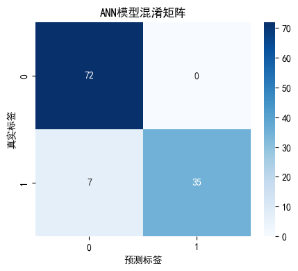

```python
cm = confusion_matrix(y_test, y_pred_class)
plt.figure(figsize=(5, 4))
sns.heatmap(cm, annot=True, fmt="d", cmap="Blues")
plt.title("ANN模型混淆矩阵")
plt.xlabel("预测标签")
plt.ylabel("真实标签")
plt.show()
```

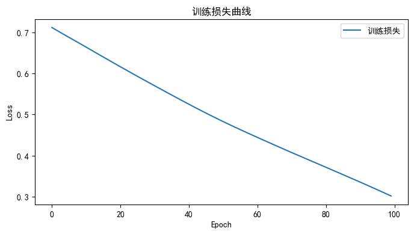

```python
plt.figure(figsize=(8, 4))
plt.plot(train_losses, label="训练损失")
plt.xlabel("Epoch")
plt.ylabel("Loss")
plt.title("训练损失曲线")
plt.legend()
plt.show()
```